# Computer_Vision_Part_4

```python
!pip install tflearn
!pip install tkinter
```

```
ERROR: Could not find a version that satisfies the requirement tkinter
ERROR: No matching distribution found for tkinter
```

```python
import tflearn.datasets.oxflower17 as oxflower17
```

```
WARNING:tensorflow:From C:\Users\patha\anaconda3\envs\tensorflow_env\lib\site-packages\tensorflow_core\python\compat\v2_compat.py:88: disable_resource_variables (from tensorflow.python.ops.variable_scope) is deprecated and will be removed in a future version.
Instructions for updating:
non-resource variables are not supported in the long term
curses is not supported on this machine (please install/reinstall curses for an optimal experience)
```

```python
X, Y = oxflower17.load_data()
```

```python
X.shape
```

```
(1360, 224, 224, 3)
```

```python
Y.shape
```

```
(1360,)
```

### Labels

```python
import numpy as np
np.unique(Y)
```

```
array([ 0,  1,  2,  3,  4,  5,  6,  7,  8,  9, 10, 11, 12, 13, 14, 15, 16])
```

We can see that there are 1360 input images with each image's size being 224x224x3.

Image Width = Image Height = 224

Number of channels in the image is 3

The images belong to 17 classes of flowers

# Visualizing the data:

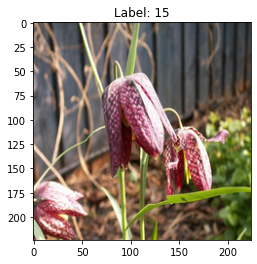

```python
import matplotlib.pyplot as plt

plt.imshow(X[0,:,:,:])
plt.title('Label: '+str(Y[0]))
```

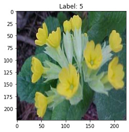

```python
plt.imshow(X[10,:,:,:])
plt.title('Label: '+str(Y[10]))
```

[figure not shown]

```python
plt.imshow(X[100,:,:,:])
plt.title('Label: '+str(Y[100]))
```

Lets convert the target variable to conhot encoded variable

```python
from sklearn.preprocessing import OneHotEncoder
Y = Y.reshape(-1, 1)
encoder = OneHotEncoder(sparse=False)
onehot_y = encoder.fit_transform(Y)
print(onehot_y)
```

```
[[0. 0. 0. ... 0. 1. 0.]
 [0. 1. 0. ... 0. 0. 0.]
 [0. 0. 0. ... 0. 0. 0.]
 ...
 [1. 0. 0. ... 0. 0. 0.]
 [0. 0. 0. ... 0. 0. 0.]
 [0. 0. 0. ... 0. 0. 0.]]
```

```python
print(onehot_y.shape)
```

```
(1360, 17)
```

```python
print(onehot_y[0:5,:])
```

```
[[0. 0. 0. 0. 0. 0. 0. 0. 0. 0. 0. 0. 0. 0. 0. 1. 0.]
 [0. 1. 0. 0. 0. 0. 0. 0. 0. 0. 0. 0. 0. 0. 0. 0. 0.]
 [0. 0. 0. 0. 0. 0. 0. 1. 0. 0. 0. 0. 0. 0. 0. 0. 0.]
 [0. 0. 0. 0. 0. 0. 0. 0. 0. 0. 0. 1. 0. 0. 0. 0. 0.]
 [1. 0. 0. 0. 0. 0. 0. 0. 0. 0. 0. 0. 0. 0. 0. 0. 0.]]
```

```python
import cv2
import numpy as np
#Lets apply various filters to Image no 4
img = X[3,:,:,:]

gray = cv2.cvtColor(img, cv2.COLOR_BGR2GRAY)
gaussianBlurKernel = np.array(([[1, 2, 1], [2, 4, 2], [1, 2, 1]]), np.float32)/9
sharpenKernel = np.array(([[0, -1, 0], [-1, 9, -1], [0, -1, 0]]), np.float32)/9
meanBlurKernel = np.ones((3, 3), np.float32)/9
edgeDetectionKernel1 = np.array(([[-1,0,1],[-2,0,2],[-1,0,1]]))
edgeDetectionKernel2 = np.array(([[-1,-2,-1],[0,0,0],[1,2,1]]))

gaussianBlur = cv2.filter2D(src=img, kernel=gaussianBlurKernel, ddepth=-1)
meanBlur = cv2.filter2D(src=img, kernel=meanBlurKernel, ddepth=-1)
sharpen = cv2.filter2D(src=img, kernel=sharpenKernel, ddepth=-1)
edge1 = cv2.filter2D(src=gray,kernel=edgeDetectionKernel1, ddepth=-1)
edge2 = cv2.filter2D(src=gray,kernel=edgeDetectionKernel2, ddepth=-1)
```

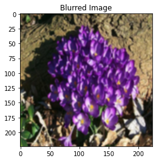

```python
import matplotlib.pyplot as plt
meanBlur.shape
plt.imshow(meanBlur)
plt.title('Blurred Image')
```

```
Clipping input data to the valid range for imshow with RGB data ([0..1] for floats or [0..255] for integers).
```

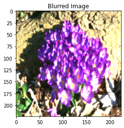

```python
plt.imshow(gaussianBlur)
plt.title('Blurred Image')
```

```
Clipping input data to the valid range for imshow with RGB data ([0..1] for floats or [0..255] for integers).
```

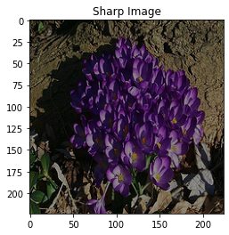

```python
plt.imshow(sharpen)
plt.title('Sharp Image')
```

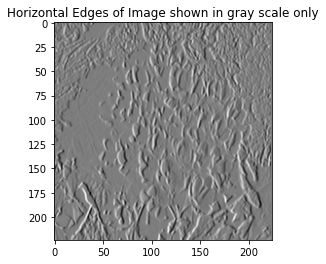

```python
plt.imshow(edge1,cmap='gray')
plt.title('Horizontal Edges of Image shown in gray scale only')
```

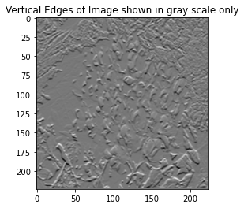

```python
plt.imshow(edge2,cmap='gray')
plt.title('Vertical Edges of Image shown in gray scale only')
```

Split the data

# SVM Model

```python
from sklearn.model_selection import train_test_split
x_train, x_test, y_train, y_test = train_test_split(X, Y, test_size=0.2,shuffle = True)
```

```python
print(x_train.shape)
print(x_test.shape)
print(y_train.shape)
print(y_test.shape)
```

```
(1088, 224, 224, 3)
(272, 224, 224, 3)
(1088, 1)
(272, 1)
```

```python
x_train1=[]
for i in range(len(x_train)):
    x_train1.append(x_train[i].flatten())

x_train1 = np.array(x_train1)


y_train1=[]
for i in range(len(y_train)):
    y_train1.append(y_train[i].flatten())

y_train1 = np.array(y_train1)
```

```python
print(x_train1.shape)
print(y_train.shape)
```

```
(1088, 150528)
(1088, 1)
```

```python
from sklearn.decomposition import PCA
pca = PCA(n_components=6)
pca.fit(x_train1)
xpca = pca.transform(x_train1)
```

```python
from sklearn import svm

clf = svm.SVC(gamma=0.025, C=3)

clf.fit(xpca , y_train)
```

```
SVC(C=3, gamma=0.025)
```

```python
x_test1=[]
for i in range(len(x_test)):
    x_test1.append(x_test[i].flatten())

x_test1 = np.array(x_test1)
xpcatest = pca.transform(x_test1)

y_pred = clf.predict(xpcatest)

from sklearn.metrics import accuracy_score
print("Accuracy for SVM model =",accuracy_score(y_test,y_pred))
```

```
Accuracy for SVM model = 0.125
```

# NN Model

```python
from sklearn.model_selection import train_test_split
X_train, X_test, y_train, y_test = train_test_split(X, onehot_y, test_size=0.2,shuffle = True)
```

```python
from tensorflow.keras.models import Sequential
from tensorflow.keras.layers import Dense,Flatten
from tensorflow.keras import regularizers,optimizers

classifier_17f = Sequential()
classifier_17f.add(Flatten())
classifier_17f.add(Dense(units=2048,activation='relu'))
classifier_17f.add(Dense(units=1024,activation='relu'))
classifier_17f.add(Dense(units=1024,activation='relu'))
classifier_17f.add(Dense(256,activation='relu'))
classifier_17f.add(Dense(128,activation='relu'))
classifier_17f.add(Dense(units=64,activation='relu'))
classifier_17f.add(Dense(units=17,activation='softmax'))

sgd =optimizers.Adam()
classifier_17f.compile(loss='categorical_crossentropy',optimizer=sgd,metrics=['accuracy'])
```

```python
#Saving the best model using model checkpoint callback
import tensorflow
model_checkpoint2=tensorflow.keras.callbacks.ModelCheckpoint('17flowers_nn.h5', #where to save the model
                                                    save_best_only=True,
                                                    monitor='val_acc',
                                                    mode='max',
                                                    verbose = 1)
from tensorflow.keras.preprocessing.image import ImageDataGenerator
img_gen = ImageDataGenerator(
    rescale=1./255,
    shear_range=0.2,
    zoom_range=0.2,
    horizontal_flip=True
    )
```

```python
history5 = classifier_17f.fit_generator(img_gen.flow(X_train*255, y_train, batch_size = 16),steps_per_epoch=int(len(X_train)/16),epochs=40,validation_data=(X_test,y_test),callbacks=[model_checkpoint2])
```

```
WARNING:tensorflow:From <ipython-input-29-6eec89caf9a5>:1: Model.fit_generator (from tensorflow.python.keras.engine.training) is deprecated and will be removed in a future version.
Instructions for updating:
Please use Model.fit, which supports generators.
WARNING:tensorflow:From C:\Users\patha\anaconda3\envs\tensorflow_env\lib\site-packages\tensorflow_core\python\ops\resource_variable_ops.py:1635: calling BaseResourceVariable.__init__ (from tensorflow.python.ops.resource_variable_ops) with constraint is deprecated and will be removed in a future vers…
Instructions for updating:
If using Keras pass *_constraint arguments to layers.

Epoch 00001: val_acc improved from -inf to 0.11397, saving model to 17flowers_nn.h5

Epoch 00002: val_acc improved from 0.11397 to 0.13235, saving model to 17flowers_nn.h5

Epoch 00003: val_acc improved from 0.13235 to 0.23529, saving model to 17flowers_nn.h5

Epoch 00004: val_acc improved from 0.23529 to 0.25000, saving model to 17flowers_nn.h5

Epoch 00005: val_acc improved from 0.25000 to 0.26838, saving model to 17flowers_nn.h5

Epoch 00006: val_acc did not improve from 0.26838

Epoch 00007: val_acc did not improve from 0.26838

Epoch 00008: val_acc improved from 0.26838 to 0.34926, saving model to 17flowers_nn.h5

Epoch 00009: val_acc did not improve from 0.34926

Epoch 00010: val_acc improved from 0.34926 to 0.36397, saving model to 17flowers_nn.h5

Epoch 00011: val_acc did not improve from 0.36397

Epoch 00012: val_acc did not improve from 0.36397

Epoch 00013: val_acc did not improve from 0.36397

Epoch 00014: val_acc did not improve from 0.36397

Epoch 00015: val_acc did not improve from 0.36397

Epoch 00016: val_acc improved from 0.36397 to 0.39706, saving model to 17flowers_nn.h5

Epoch 00017: val_acc did not improve from 0.39706
```

[output cut: 31 more lines]

```
Epoch 00033: val_acc did not improve from 0.51838

Epoch 00034: val_acc did not improve from 0.51838

Epoch 00035: val_acc did not improve from 0.51838

Epoch 00036: val_acc did not improve from 0.51838

Epoch 00037: val_acc did not improve from 0.51838

Epoch 00038: val_acc improved from 0.51838 to 0.52574, saving model to 17flowers_nn.h5

Epoch 00039: val_acc did not improve from 0.52574

Epoch 00040: val_acc did not improve from 0.52574
```

# CNN Model

```python
from tensorflow.keras.models import Sequential
from tensorflow.keras.layers import Conv2D
from tensorflow.keras.layers import MaxPooling2D
from tensorflow.keras.layers import Flatten
from tensorflow.keras.layers import Dense,Dropout
from tensorflow.keras.optimizers import Adam
from tensorflow.keras.layers import BatchNormalization

model = Sequential()
model.add(Conv2D(96, kernel_size=(11, 11), strides=(4, 4), activation='relu', input_shape=(224, 224, 3)))
model.add(MaxPooling2D(pool_size=(3, 3), strides=(2, 2)))
model.add(BatchNormalization())

model.add(Conv2D(256, kernel_size=(5, 5), activation='relu'))
model.add(MaxPooling2D(pool_size=(3, 3), strides=(2, 2)))
model.add(BatchNormalization())

model.add(Conv2D(256, kernel_size=(3, 3), activation='relu'))
model.add(Conv2D(384, kernel_size=(3, 3), activation='relu'))
model.add(Conv2D(384, kernel_size=(3, 3), activation='relu'))
model.add(MaxPooling2D(pool_size=(3, 3), strides=(2, 2)))
model.add(BatchNormalization())

model.add(Flatten())
model.add(Dense(4096, activation='relu'))
model.add(Dropout(0.5))
model.add(Dense(4096, activation='relu'))
model.add(Dropout(0.5))

model.add(Dense(17, activation='softmax'))
```

```python
model.summary
```

```
<bound method Network.summary of <tensorflow.python.keras.engine.sequential.Sequential object at 0x0000029E918D75C0>>
```

```python
model.compile(optimizer=Adam(),loss = 'categorical_crossentropy',metrics=['accuracy'])
```

```python
y_train.shape
```

```
(1088, 17)
```

```python
#Saving the best model using model checkpoint callback
import tensorflow
model_checkpoint=tensorflow.keras.callbacks.ModelCheckpoint('17flowers.h5', #where to save the model
                                                    save_best_only=True,
                                                    monitor='val_acc',
                                                    mode='max',
                                                    verbose = 1)
history4 = model.fit_generator(img_gen.flow(X_train*255, y_train, batch_size = 16),steps_per_epoch=int(len(X_train)/16),epochs=40,validation_data=(X_test,y_test),callbacks=[model_checkpoint])
```

```
Epoch 00001: val_acc improved from -inf to 0.06250, saving model to 17flowers.h5

Epoch 00002: val_acc improved from 0.06250 to 0.27941, saving model to 17flowers.h5

Epoch 00003: val_acc improved from 0.27941 to 0.29412, saving model to 17flowers.h5

Epoch 00004: val_acc improved from 0.29412 to 0.47794, saving model to 17flowers.h5

Epoch 00005: val_acc did not improve from 0.47794

Epoch 00006: val_acc did not improve from 0.47794

Epoch 00007: val_acc did not improve from 0.47794

Epoch 00008: val_acc did not improve from 0.47794

Epoch 00009: val_acc did not improve from 0.47794

Epoch 00010: val_acc did not improve from 0.47794

Epoch 00011: val_acc did not improve from 0.47794

Epoch 00012: val_acc did not improve from 0.47794

Epoch 00013: val_acc did not improve from 0.47794

Epoch 00014: val_acc did not improve from 0.47794

Epoch 00015: val_acc improved from 0.47794 to 0.51103, saving model to 17flowers.h5

Epoch 00016: val_acc did not improve from 0.51103

Epoch 00017: val_acc did not improve from 0.51103

Epoch 00018: val_acc did not improve from 0.51103

Epoch 00019: val_acc did not improve from 0.51103

Epoch 00020: val_acc did not improve from 0.51103

```

[output cut: 24 more lines]

```
Epoch 00033: val_acc did not improve from 0.59559

Epoch 00034: val_acc did not improve from 0.59559

Epoch 00035: val_acc did not improve from 0.59559

Epoch 00036: val_acc improved from 0.59559 to 0.60294, saving model to 17flowers.h5

Epoch 00037: val_acc did not improve from 0.60294

Epoch 00038: val_acc did not improve from 0.60294

Epoch 00039: val_acc improved from 0.60294 to 0.60662, saving model to 17flowers.h5

Epoch 00040: val_acc did not improve from 0.60662
```

### CNN model is outperforming the rest two so we will use cnn for predicting the image

The Machine Learning model makes decisions according to what it has learned from the data, Neural Networks arranges algorithms in a fashion that it can make accurate decisions by themselves.

Although Machine Learning models can learn from data, in the initial stages, they require some human intervention.

Neural networks do not require human intervention as the nested layers within pass the data through hierarchies of various concepts, thus making them capable of learning through their errors.

NNs can learn and model non-linear and complex relationships. It is critical in real-life because many of the relationships between inputs and outputs are non-linear and complex.

Why CNN better than Neural Networks?

The main advantage of CNN compared to NN is that it automatically detects the essential features without any human supervision. For example - given many pictures of cats and dogs, it can learn the key traits for each class by itself.

CNN is better than a feed-forward network since CNN has features parameter sharing and dimensionality reduction. Because of parameter sharing in CNN, the number of parameters is decreased. Thus the computations also reduced.

# GUI

```python
import tkinter as tk
from tkinter import ttk
import re
from tkinter import filedialog
import cv2
import numpy as np
win = tk.Tk()
win.title(' Classifier-Convolutional Neural Networks GUI')
Name = ttk.Label(win,text="Step 1: File Name",width=25)
Name.grid(row=0,column=0,sticky=tk.W)
Name_var = tk.StringVar()
Name_entrybox = ttk.Entry(win,width=16,textvariable=Name_var)
Name_entrybox.grid(row=0,column=1)
def browsefunc():
    filename = filedialog.askopenfilename()
    print(filename)
    Name_var.set(filename)
def predictfunc():
    test_image = cv2.imread(Name_var.get())
    test_image = cv2.resize(test_image,(224,224))
    import numpy as np
    test_image = np.expand_dims(test_image,axis=0)
    test_image = test_image
    pre_trained_model2 = tensorflow.keras.models.load_model('17flowers.h5')
    result = pre_trained_model2.predict(test_image)
    predicted_index = np.argmax(result[0])
    print(predicted_index)
    print(result)


    confirm_entrybox = ttk.Entry(win,width=16)
    confirm_entrybox.grid(row=3,column=1,sticky=tk.W)
    confirm_entrybox.insert(1,str(predicted_index))


browsebutton = ttk.Button(win, text="Browse", command=browsefunc)
browsebutton.grid(row=0,column=2)
CNN = ttk.Label(win,text="Classifier-CNN",width=25)
CNN.grid(row=1,column=0,sticky=tk.W)
predictbutton = ttk.Button(win, text="Predict", command=predictfunc)
predictbutton.grid(row=2,column=1)
Result = ttk.Label(win,text="Predicted Class",width=25)
Result.grid(row=3,column=0)
win.mainloop()
```

```
C:/Users/patha/Desktop/Great Learning/Computer Vision/Week 3 Project/Prediction - Flower.jpg
WARNING:tensorflow:From C:\Users\patha\anaconda3\envs\tensorflow_env\lib\site-packages\tensorflow_core\python\ops\init_ops.py:97: calling GlorotUniform.__init__ (from tensorflow.python.ops.init_ops) with dtype is deprecated and will be removed in a future version.
Instructions for updating:
Call initializer instance with the dtype argument instead of passing it to the constructor
WARNING:tensorflow:From C:\Users\patha\anaconda3\envs\tensorflow_env\lib\site-packages\tensorflow_core\python\ops\init_ops.py:97: calling Zeros.__init__ (from tensorflow.python.ops.init_ops) with dtype is deprecated and will be removed in a future version.
Instructions for updating:
Call initializer instance with the dtype argument instead of passing it to the constructor
WARNING:tensorflow:From C:\Users\patha\anaconda3\envs\tensorflow_env\lib\site-packages\tensorflow_core\python\ops\init_ops.py:97: calling Ones.__init__ (from tensorflow.python.ops.init_ops) with dtype is deprecated and will be removed in a future version.
Instructions for updating:
Call initializer instance with the dtype argument instead of passing it to the constructor
2
[[0. 0. 1. 0. 0. 0. 0. 0. 0. 0. 0. 0. 0. 0. 0. 0. 0.]]
```

### We have predicted Class 2 for the given image using the model which best fits our problem